# **CSP2018** - Conference on Statistical Practice

Jan 16, 2018

Documentation of the [American Statistical Association’s](http://www.amstat.org/) [2018 Conference on Statistical Practice](http://www.amstat.org/meetings/csp/2018/), Feb 15-17, 2018 in Portland, OR.

# 1 Goals

Provide conference attendees with the opportunity to

- Learn new statistical methodologies and best practices in statistical analysis, design, consulting, and statistical programming.
- Further career development and strengthen relationships in the statistical community.

# 2 Themes

## 2.1 Communication, Collaboration and Career Development

The objective for this theme is to help conference participants develop skills and perspectives that will improve their personal and professional effectiveness as statisticians and increase their organizational impact as managers, leaders, strategists, consultants or collaborators. Presentations will enable participants to return to their jobs with new ideas, techniques, and strategies for improving their ability to assume leadership roles, communicate effectively, forge productive professional relationships, and develop and advance their careers. Potential topics include the following:

- Organizational impact and influence
- Leadership and management
- Mentoring
- Effective communication
- Presenting statistical results to nonstatisticians
- Best practices in consulting and collaboration
- Career development and advancement
- Statistical ethics

## 2.2 Data Modeling and Analysis

The objective for this theme is to provide attendees with practical knowledge about modeling and analyzing data of various forms through the application of state-of-the-art statistical methods. Presentation methods should use illustrative data analysis examples reproducible across several statistical packages and may focus on a variety of data types from varied applied settings. Presentations will feature information relevant to a broad range of applied statisticians working in diverse settings. Potential topics include the following:

- Modeling
- Inference
- Prediction

## 2.3 Data Science and Big Data

Data Science and Big Data are at the forefront of statistical practice and require a complex set of computing, statistical and communication skills. This conference theme aims to help practitioners working in these fields stay current with state-of-the-art methods for solving inference, prediction, decision making, classification, and pattern recognition problems from extremely large, unconventional, or complex data. Presentations pertaining to this theme will involve large data applications, overviews/surveys of methodological tools and algorithms for solving such applications and best practices for gathering, structuring, exploring, visualizing and analyzing large amounts of data. Potential topics include the following:

- Capturing, exploring, and visualizing large amounts of raw data
- Processing and cleaning raw data to produce analyzable data structures
- Scaling up statistical models for Data Science and Big Data applications
- Analysis techniques for high-throughput screening
- Text analytics and sentiment analysis
- Model validation and comparison approaches

## 2.4 Software, Programming, and Data Visualization

The objective for this theme is to help attendees integrate new or existing software, statistically oriented programming languages (R, SAS, etc.), or general programming languages (Python, Java, etc.) into their current processes. Presentations will focus on the practical application of such technology for the statistician or data analyst. Potential topics include the following:

- Software and programming methods to obtain, clean, describe, or analyze data
- Methods for interactively sharing analysis results with other analysts or end users
- Visualization methods for communication and data discovery
- Statistical applications of general programming languages

# 3 Steering Committee

## 3.1 Charge

The Conference on Statistical Practice Steering Committee (CSPSC) is responsible for the program and organization of the annual Conference on Statistical Practice (CSP). The purpose of the conference is to bring together statistical practitioners (including data analysts, researchers and scientists) who engage in the application of statistics to solve real-world problems to provide them opportunities to learn about the latest statistical methodologies and best practices in statistical design, analysis, programming and consulting, and aid them in improving their abilities in consulting with and helping customers and organizations. In conjunction with ASA staff, the CSPSC will make policy decisions for the conference, set and evaluate conference goals in accordance with needs of the target audiences, select sites and dates, recommend registration and other fees, pursue sponsorships, and actively promote the conference.

## 3.2 Composition

The CSPSC will consist of up to fifteen members. Six of these are appointed by the President-Elects. Each President-Elect will appoint/reappoint three of these six members for two year terms. One of these three appointments is a vice-chair, who serves a one year term and then becomes chair for one year. The CSPSC Chair, in consultation with the remaining committee members, has the authority to appoint additional members (up to the maximum of 15 members) for 1-2 year terms in order to provide the diversity of statistical practice needed to round out the planning of the conference.

## 3.3 Members

Visit the ASA’s [Committee webpage](http://ww2.amstat.org/committees/commdetails.cfm?txtComm=CCNORG08) for more information on past and current members of the CSP Steering Committee.

|  | Name | Affiliation | Location | Appointment | Position | Expiration |
| --- | --- | --- | --- | --- | --- | --- |
| 1 | Adams, Jean V. | USGS Great Lakes Science Center | Antigo, WI | President-Elect | Chair | 2/28/2018 |
| 2 | Vance, Eric | University of Colorado Boulder | Boulder, CO | President-Elect | Vice-Chair | 2/28/2019 |
| 3 | Dohrmann, Sylvia Miller | Westat | Rockville, MD | President-Elect | Member | 2/28/2018 |
| 4 | Martinez, Wendy L. | Bureau of Labor Statistics | Fredericksburg, VA | President-Elect | Member | 2/28/2019 |
| 5 | Schweitzer, Laura G. | PriceWaterhouseCoopers | Gaithersburg, MD | President-Elect | Member | 2/28/2018 |
| 6 | Stephens, Eric B. | Vanderbilt University Medical Center | Nashville, TN | President-Elect | Member | 2/28/2018 |
| 7 | Corliss, David J. | Ford Motor Company | Plymouth, MI | Chair | Member | 2/28/2018 |
| 8 | Gao, Jinguo | Google Inc. | San Jose, CA | Chair | Member | 2/28/2019 |
| 9 | Ghement, Isabella | Ghement Statistical Consulting Company Ltd. | Richmond, BC | Chair | Member | 2/28/2018 |
| 10 | Jones, Edward R. | Texas A&amp;M Statistical Services | College Station, TX | Chair | Member | 2/28/2019 |

[output cut: 5 more lines]

[interactive chart not shown]

## 3.4 Subcommittees

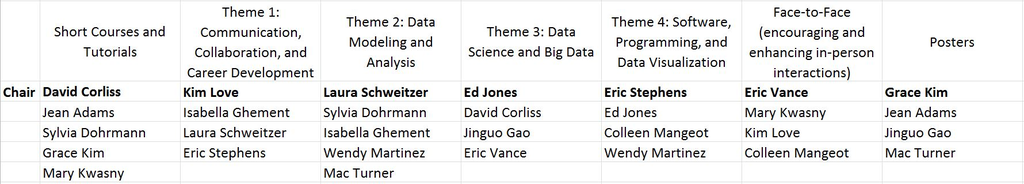

## 3.5 ASA Staff

- Amanda Conageski - Meetings Planner
- Donna LaLonde - Director of Strategic Initiatives and Outreach

# 4 Time Line

## 4.1 Visualization of Events and Tasks

Interactive time line of CSP2018 tasks and events.

- Hover your mouse over event to get more information.
- Pan or zoom to see other dates.

The color corresponds to the group responsible for each task.

- Steering Committee - bold black labels
- ASA - maroon labels
- Attendees, Presenters, etc. - blue labels

[interactive chart not shown]

## 4.2 Table of Events and Tasks

The interactive table below shows the data behind the calendar above.

- Search for any text in the table.
- Sort by column.
- Filter rows choosing a data range, a task category, or person responsible.

| Order | Start | End | Category | Who | Task |
| --- | --- | --- | --- | --- | --- |
| 1 |  | 2017-02-25 | General | Chair | Formation of subcommittees |
| 2 |  | 2017-02-25 | SC Meetings | Steering Committee | CSP2018 lunch meeting at CSP2017 |
| 3 |  | 2017-02-28 | General | Theme Subcommittees | Review themes |
| 4 |  | 2017-03-02 | Oral Sessions | Steering Committee | Final program tracks due from Committee |
| 5 |  | 2017-03-02 | General | Steering Committee | Invited Session criteria finalized by Committee |
| 6 | 2017-03-04 | 2017-03-18 | Courses | Steering Committee | Generate list of instructors to invite |
| 7 | 2017-03-04 | 2017-03-18 | Oral Sessions | Steering Committee | Generate list of presenters to invite |
| 8 |  | 2017-03-30 | Courses | Steering Committee | Review call for short course and tutorial abstracts |
| 9 |  | 2017-04-05 | SC Meetings | Steering Committee | Conference call |
| 10 |  | 2017-04-06 | Oral Sessions | Steering Committee | Final invited presenter list due from Committee |

[output cut: 51 more lines]

# 5 Documents

## 5.1 Invitations

### 5.1.1 Short course and tutorial instructors

On behalf of ASA President Barry Nussbaum, it is my pleasure to invite you to present a short course or tutorial at the 2018 Conference on Statistical Practice (CSP). The conference provides an important venue for statisticians and data scientists, at all levels of the career spectrum, to interact both formally and informally. One of the hallmarks of the conference is the availability of short courses and tutorials that address the conference themes of Communication, Collaboration, and Career Development; Data Modeling and Analysis; Data Science and Big Data; and Software, Programming, and Data Visualization. Your participation will contribute to the quality of the program and the positive trajectory of this conference. Your invitation reflects the CSP Steering Committee’s recognition of your stature in the field, so I hope you will be able to present a short course or tutorial at CSP 2018.

CSP 2018 will be held in Portland, OR on February 15-17, 2018. Full day and half day short courses will be offered on Thursday, February 15 and two-hour tutorials will be offered on Saturday, February 17. Short course and tutorial instructors receive complimentary conference registration and an honorarium. The honorarium is $1,000 for a full day short course, $500 for a half day short course, and $250 for a two-hour tutorial.

Please reply to this email by April 22, 2017 to indicate your acceptance or refusal of the invitation as well as your presentation preference (full day short course, half day short course, or two-hour tutorial). By accepting, you agree to submit an abstract by May 11, 2017, and your course or tutorial is guaranteed to be included in the conference program.

Please feel free to reply to this e-mail if you require additional information or have any questions.

Thank you for your consideration.

### 5.1.2 Oral presentation speakers

On behalf of ASA President Barry Nussbaum, it is my pleasure to invite you to give an oral presentation at the 2018 Conference on Statistical Practice (CSP). The conference provides an important venue for statisticians and data scientists, at all levels of the career spectrum, to interact both formally and informally. One of the hallmarks of the conference is the availability of 45-minute presentations that address the conference themes of Communication, Collaboration, and Career Development; Data Modeling and Analysis; Data Science and Big Data; and Software, Programming, and Data Visualization. Your participation will contribute to the quality of the program and the positive trajectory of this conference. Your invitation reflects the CSP Steering Committee’s recognition of your stature in the field, so I hope you will be able to give an oral presentation at CSP 2018.

CSP 2018 will be held in Portland, OR on February 15-17, 2018. Oral presentations will be offered on Friday and Saturday, February 16 and 17.

Please reply to this email by May 26, 2017 to indicate your acceptance or refusal of the invitation. By accepting, you agree to submit an abstract by June 22, 2017, and your presentation is guaranteed to be included in the conference program.

Please feel free to reply to this e-mail if you require additional information or have any questions.

Thank you for your consideration.

## 5.2 Calls for abstracts

### 5.2.1 Short courses and tutorials

Do you have a full-day short course, half-day short course, or two-hour tutorial you would like to teach at the 2018 Conference on Statistical Practice? Proposals must be submitted by May 11, 2017 and should touch on one of the following four broad themes:

*[Theme descriptions above inserted here.]*

**What to Include in Your Submission**

There are a limited number of slots available. Successful presentations have the following characteristics:

1. Immediate practical value from the course
2. Clearly relevant to the conference goals and themes
3. Objective(s) of the course are clear and specific
4. Evidence there will be audience engagement/participation with interactive exercises
5. Titles/content that create interest and/or clearly describe the deliverable

Each proposal submission must include the following:

- Course Type (full-day short course, half-day short course, or two-hour tutorial)
- Course Title
- Course Description
  - Outline and Objectives: Course abstract, outline, scope, objectives, intended level, and any prerequisites
  - Instructor Qualifications: Qualifications must demonstrate expertise in the course topic and may include education, special training or study, work experience or previous papers, presentations, or courses on the topic.
  - Relevance to Conference Goals: A brief discussion about how the course will enable participants to immediately achieve the conference goals (as follows):
    - Learn statistical methods or programming techniques that apply to their job as applied statisticians
    - Better communicate and collaborate with their clients and customers
    - Have a positive effect on their organization or enhance their professional development
- Software Packages
  - Course proposals and abstracts must note software packages that will be used during the course.
- Instructor name(s) and affiliation(s)

Note that any use or focus on software for courses should only be to highlight the statistical application or technique, and not to promote or sell software. Specifically:

1. Proposed courses that focus on teaching statistical topics should be developed so the knowledge learned can be applied using a variety of software packages and textbooks. Participants in the course should not have to purchase any software or other products to participate. In addition, although participants may have to purchase software to apply the technique outside the course, they should not have to purchase the specific software used by the course instructor for illustrative purposes. Specific software packages may be used to illustrate course concepts and, if possible, the instructor should inform the course students of alternative software packages that can be used.
2. Proposals and abstracts for courses teaching statistical programming techniques must clearly specify that programming, not methodology, is the focus of the course. They must also state what software packages will be used during the course and whether these packages are commercial or open-source. If the packages are commercial in nature, the proposals and abstracts must indicate whether the participants will be provided with access to a working version of the software during the course.

If these criteria are not met, please consider submitting your topic in the Practical Computing Demo [link].

### 5.2.2 Oral presentations

- Communication, Collaboration and Career Development
- Data Modeling and Analysis
- Data Science and Big Data
- Software, Programming, and Data Visualization

**What to Include in Your Abstract Submission**

Only a limited number of abstracts will be accepted. We are looking for abstracts that:

- Interest and entice statistical practitioners from a variety of industries
- Provide opportunities for audience engagement and participation, e.g., interactive exercises, audience questions/surveys, etc.
- Describe the intended audience, including the primary application area(s) and content level (introductory, intermediate, or advanced)
- Demonstrate relevance to the conference goals and themes
- State clear and specific objectives
- Provide immediate practical value to the audience (handouts and on-line materials encouraged), e.g., enabling them to
  - Apply a statistical technique in their job as applied statisticians
  - Better communicate with their clients and customers
  - Positively impact their organization or enhance their professional development

Each abstract submission should also include:

- Presentation title, abstract, and presenter name(s) and affiliation(s)
- Qualifications of the presenter(s), demonstrating expertise in the presentation topic, e.g., education, training, experience, or previous papers or presentations on the topic
- List of any software you are using. Any reference to software should only be to illustrate your ideas and applications, not to sell the software.

We look forward to receiving your abstract submissions for concurrent session presentations.

*[Theme descriptions above inserted here.]*

### 5.2.3 Posters

Would you like to share your experience as a statistical practitioner solving real-world problems? If so, an electronic poster presentation is a great way to do so while having an extended face-to-face discussion with others interested in your topic. A poster presentation also serves as an excellent teaching tool, allowing for direct and immediate feedback; broad exposure; and the ability to display extensive graphics, tables, and animations.

We invite you to submit your abstract for an electronic poster presentation at the Conference on Statistical Practice 2018. The submission deadline is August 31, 2017. You will have 75-90 minutes to engage your audience in one of the following four broad themes (described more fully below):

- Communication, Collaboration and Career Development
- Data Modeling and Analysis
- Data Science and Big Data
- Software, Programming, and Data Visualization

**What to Include in Your Abstract Submission**

Only a limited number of abstracts will be accepted. We are looking for abstracts that:

- Interest and engage statistical practitioners from a variety of industries
- Describe the intended audience, including the primary application area(s) and content level (introductory, intermediate, or advanced)
- Demonstrate relevance to the conference goals and themes
- State clear and specific objectives
- Provide immediate practical value to the audience (handouts and on-line materials encouraged), e.g., enabling them to
  - Apply a statistical technique in their job as applied statisticians
  - Better communicate with their clients and customers
  - Positively impact their organization or enhance their professional development Each abstract submission should also include:
- Poster title, abstract, and poster presenter name(s) and affiliation(s)
- Qualifications of the presenter(s), demonstrating expertise in the poster topic, e.g., education, training, experience, or previous papers or presentations on the topic
- List of any software you are using. Any reference to software should only be to illustrate your ideas and demonstrate their practical implementation and applications, rather than advertise the software itself or convince conference participants to purchase it.

Single-slide posters with hyperlinks to graphics or background information are preferred; if a multiple-slide poster is used, we recommended no more than four slides be included. Presenters should also have a one-minute “elevator pitch” prepared to orally present and summarize their material. For more information about the poster format, see [Poster Presentation Tips](https://ww2.amstat.org/meetings/csp/2018/postertips.cfm).

Students are encouraged to submit an abstract. This year, as in previous years, there will be an award for the best student poster. All student posters presented at CSP2018 will be evaluated by a panel of four judges at the conference. The judges will evaluate each student poster on the topic, methods used, and presentation of the material visually and orally. The award for the best student poster will be announced at the Closing General Session of the conference (4:15 p.m. Saturday) and reported by the ASA on Facebook and Twitter and in Amstat News. The winner will be given a certificate from the ASA and a one-year student membership.

We look forward to receiving your abstract submissions for poster presentations.

*[Theme descriptions above inserted here.]*

## 5.3 Response Emails

### 5.3.1 Oral presentation - accepted

Dear «FirstName» «LastName»,

We are excited to include your presentation — abstract number «AbstractID», “«AbstractTitle»” — in the 2018 ASA Conference on Statistical Practice at the Marriott Portland Downtown Waterfront in Portland, Oregon, February 15-17, 2018. Your presentation is scheduled for «SessionDate» at «SessionBeginTime», and we look forward to it being part of this year’s informative and insightful program.

We truly appreciate your participation in the seventh year of the Conference on Statistical Practice. To secure your place on the conference program, you are required to register for the conference by Thursday, November 16, 2017. We also ask that you post your presentation slides to the secure online program during Jan 9 - Feb 13, 2018 so attendees can access them prior to the conference. We will provide you with the link for slide upload in early January. The presentations will be password protected, and you will retain the copyright to your material.

Please make a note of the following dates that are key to the success of the conference.

Prior to the abstract editing period, a member of the CSP Steering Committee may contact you to discuss how your presentation fits into the session and conference. A session ambassador representing the committee will help you connect with the other speaker(s) in your session and will also be happy to provide feedback on your session slides before you finalize them. The session chair will contact you for your biographical information.

Congratulations again on being accepted onto the program! Please feel free to contact Meetings@amstat.org if you have any questions.

Sincerely,

Conference on Statistical Practice Steering Committee

## 5.4 Best Student Poster Guidelines

- Student contributed papers are identified.
- All student contributed posters are evaluated by a panel of four judges (volunteers from the steering committee).
- Each judge evaluates each student posters based on the following criteria, and provides the names of their top three posters (ranked 1, 2, and 3) to **designee**, by 3:00 pm Saturday.
  - Topic: Relevant? Important?
  - Presentation: Logical? Interesting? Clear?
  - Methods: Well designed? Appropriate?
  - Visuals: Effective? Informative?
  - Interview: Knowledgeable? Conversant?
- **Designee** assigns 3 points to each poster that earned a #1 ranking, 2 points to each that earned a #2, and 1 point to each that earned a #3.
- The poster(s) with the most points is selected as the Best Student Poster.
- The award is announced at the closing ceremony (4:15 pm Saturday), and the presenter is given an official certificate from ASA, and a photo is taken.
- The award is also reported by ASA on Facebook, Twitter, and AmStat News.

## 5.5 Post-Conference Survey

# 6 Meeting Minutes

## 6.1 Feb 25, 2017 (at CSP)

*[Minutes by Jean]*

12:30 - 2:00 PM, Hyatt Regency restaurant, Jacksonville

- Present: Grace Kim, Eric Vance (vice chair), Sylvia Dohrmann, David Corliss, Laura Schweitzer, Ed Jones, Kim Love, Mary Kwasny, Eric Stephens, Colleen Mangeot, Jean Adams (chair), Isabella Ghement, Donna LaLonde (ASA)
- Absent: Wendy Martinez, Jinguo Gao, Mac Turner, Amanda Conageski (ASA)

### 6.1.1 Paired Introductions

### 6.1.2 Goals of CSP

### 6.1.3 Approaching deadlines

- Mar 2 – Invited Session Criteria finalized by Committee
- Mar 2 – Final program tracks due from Committee
- Apr 5 – Steering Committee Conf. Call, 4 pm Eastern Time (1P, 2M, 3C)
- Apr 6 – Final Invitation List due from Committee – This deadline was pushed back (from Apr 4 to Apr 6) so that it occurs after our next conference call.
- Feb 15-17, 2018 – [CSP2018](https://ww2.amstat.org/meetings/csp/2018/) in Portland, OR

### 6.1.4 Invited vs. Open Call Sessions

- For CSP2017, we extended invitations to short course and tutorial instructors and Theme 3 Data Science and Big Data presenters. These invitations were sent by ASA and guaranteed non-competitive inclusion in the program if the invitee accepted. This was then followed up with an open call for additional instructors and presenters. For the other three themes, only an open call for abstracts was extended.
- For CSP2018, we agreed to repeat this combined invitation and open call approach and extend it to the other three themes as well. We believe the resulting increase in quality of courses/presentations at CSP2018 is worth the additional effort required by the Steering Committee and ASA to extend these invitations.
- **ACTION:** All Steering Committee members (regardless of subcommittee membership) will send suggested people to invite by **Mar 18** for
  - invited instructors to David and
  - for invited presenters to the appropriate theme chair:
    - Kim for Communication, Collaboration and Career Development,
    - Laura for Data Modeling and Analysis,
    - Ed for Data Science and Big Data, and
    - Eric Stephens for Software, Programming, and Data Visualization.
  - Each person should submit at least 1 suggestion for an invited instructor and at least 1 suggestion for an invited presenter (more are welcome). For each invitee, provide a name, email address, affiliation, and brief description of what they will bring to the CSP. The Short Course subcommittee and the 4 theme subcommittees will then review the suggestions, and share their recommendations for invitations with the entire steering committee **Mar 29**.
- **ACTION:** The Short Course and Tutorial subcommittee will review the call for short course abstracts and submit a revised document to the full committee by **Mar 23**. The full committee will have one week to comment on the revisions before the call is due to ASA, **Mar 30**. Suggestions to consider from our meeting include:
  - clarify that there are only a limited number of slots open
  - clearly state how the abstracts will be judged
  - ask the submitter what they want the audience to take away from their course/talk (the deliverable) and how they plan to make this happen
  - encourage instructors/presenters to engage their audience with interactive exercises.
- We discussed ways to determine whether an abstract submitter would give a quality course/presentation, e.g., ask for CV, ask for inclusion of example table or figure, ask for 30 second video abstract. Disadvantages to all of these is the additional work it requires by the committee members reviewing the abstracts and the management of the documents/links. Additional disadvantages of videos include (1) possible deterrent effect even on quality instructors/presenters and (2) possible concern about how those videos would be judged. **ACTION:** The Communication, Collaboration and Career Development subcommittee will further discuss and consider the optional use of video for abstracts submitted to the CCCD theme, and share their recommendation with full committee **Mar 29**. The call for oral presentation abstracts is not due until May 9.

### 6.1.5 Program tracks (theme descriptions) – due Mar 2

- **ACTION:** Steering Committee chairs work with your subcommittees to review the theme descriptions. Send the final product to Jean by noon Eastern time, **Mar 2**.

### 6.1.6 Subcommittee assignments (chair names in bold)

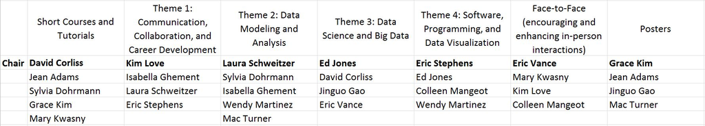

### 6.1.7 Miscellany

- To encourage attendance at Saturday morning talks, we suggest that lights in the breakfast area be turned off and on just before the talks begin.
- We very briefly discussed scheduling, e.g., the timing of the keynote address. Amanda tells me that ASA’s request for hotel bids included a schedule in it. So, to change the CSP schedule we will need to recommends changes (with justification) for review by ASA staff and potential consult with hotel.
- Possible idea for ASA to generate interest in CSP: create and share short video(s) of invited instructors.

## 6.2 Apr 5, 2017

*[Minutes by Jean]*

- Present (**100%!!**): Amanda Conageski (ASA), Colleen Mangeot, David Corliss, Donna LaLonde (ASA), Ed Jones, Eric Stephens, Eric Vance (vice chair), Grace Kim, Isabella Ghement, Jean Adams (chair), Jinguo Gao, Kim Love, Laura Schweitzer, Mac Turner, Mary Kwasny, Sylvia Dohrmann, Wendy Martinez

### 6.2.1 Approaching items in timeline

- Apr 6 – Final Invitation Lists due from Committee
- Apr 6 - May 11 – Short course and tutorial abstract submission
- Apr 7 – Invitations sent to instructors and presenters
- Next Meeting – week of May 1-5?? - Jean will send Doodle poll
- May 9 – Review call for oral presentation abstracts
- May 11 – Acceptance deadline for invitees
- May 14 - Jun 6 – Review and selection of short courses and tutorials
- May 16 - Jun 22 – Concurrent oral abstract submission

### 6.2.2 Invited Instructors

- Approach: We looked at people that were listed under both the instructors and the speakers invitation list, and decided how we would prefer they contribute to the conference. We trimmed back on those whose primary topics seemed to overlap quite a bit. We removed any members of the steering committee to avoid any appearance of impropriety. We looked to see if there were any major gaps in the topics that were covered. Topics that we should keep an eye out for in the open call for short courses include: **text analytics, mixed models, plotly (multiple software), flexdashboard (R) and Shiny dashboard (R)**.
- Cheryl Caldwell
- Kelly McConville
- David Dickey
- Mark Ward
- Keith Baggerly
- Denisa Roberts
- Karl Broman
- Shivnath Babu
- Alberto Cairo
- Scott Murray
- Wes McKinney
- Hadley Wickham
- Garrett Grolemund

### 6.2.3 Invited Presenters

- Communication, Collaboration and Career Development
  - Sally Morton
  - Doug Zahn
  - Cole Nussbaumer Knaflic
  - Jennifer Van Mullekom
  - Janice Derr
- Data Modeling and Analysis
  - None
- Data Science and Big Data
  - Roger Peng
  - Jeff Leek
  - Fei-Fei Li
  - Chris Hans
  - Chris Holloman
  - Hilary Parker
  - Drew Conway
- Software, Programming, and Data Visualization
  - Katy Börner
  - Nathan Yau
  - David Beazley
  - Heather Krause

### 6.2.4 Call for Oral Presentation Abstracts

- Use of videos - Kim, CCCD - Discussion tabled for our next meeting

## 6.3 Apr 28, 2017

*[Minutes by Jean]*

### 6.3.1 Approaching items in timeline

- Apr 22 - Acceptance deadline for invited instructors
- May 1 - Review call for oral presentation abstracts
- May 14 - Jun 6 - Review and selection of short courses and tutorials
- May 16 - Invitations sent to presenters
- May 16 - Jun 22 - Concurrent oral abstract submission
- May 26 - Acceptance deadline for invited presenters
- May 30 - Jun 5 ?? - Next conference call
- Jun 3 - 10 - Selection of JSM talks that CSP will sponsor

### 6.3.2 Use of Videos in Addition to Oral Presentation Abstracts

- A video abstract would be an optional addition to the required written abstract. A time limit should be imposed, e.g., no more than 30 seconds or 2 minutes. What is the incentive for someone to submit a video abstract? It’s an opportunity for someone to demonstrate their presentation skills. Could shine the light on an unknown engaging speaker we might otherwise overlook. It would be helpful for one of us to create a video as an example for submitters to view. Submitters would provide a link to their video (e.g., YouTube). A file sharing location (like Dropbox) may provide more anonymity. We can add an optional fourth question to the abstract submission form, where submitters would place their link. Submitters should be discouraged from simply reading their abstracts. If not everyone submits an abstract, what sort of bias is introduced in the selection process? We could target the short course submitters for video abstracts, they are typically more experienced at delivering oral content. The videos could be used to inform the selection of short courses by both we Steering Committee members and by CSP registrants. What problem are we trying to solve with these video abstracts? Might we do this better by providing *all* submitters and presenters with advice on creating a good presentation? **ACTION:** The Communication, Collaboration and Career Development subcommittee will incorporate the suggestions raised during this meeting and prepare a formal recommendation back to the group by **Jun 15**. If the recommendation is to proceed with a pilot, then include verbiage for the call for abstracts. The full Steering Committee will review and revise the recommendation to be passed on to the CSP2019 Steering Committee.

### 6.3.3 Review Call for Oral Presentation Abstracts

- Put the theme descriptions at the end; that way they will still be easily accessible without breaking up the call itself. Is there another word for “presentation” that implies a more interactive and dynamic audience engagement? *PresEngagment*? Be clear who the target audience is. Tell us what software (if any) you used. Communication is part of statistical *practice*. Should we have more presentation on making better presentations? We typically do have one presentation-focused presentation at CSP. **ACTION:** Steering Committee members will send their suggested edits to Jean by **Apr 28**. She will circulate a revised version Monday morning **May 1**, before sending the final version that afternoon.

## 6.4 Jun 2, 2017

*[Minutes by Jean]*

- Present: Amanda Conageski (ASA), Donna LaLonde (ASA), Mac Turner, Sylvia Dohrmann, Mary Kwasny, Eric Stephens, Eric Vance (vice chair), Wendy Martinez, Grace Kim, David Corliss, Jean Adams (chair), Laura Schweitzer, Kim Love
- Absent: Colleen Mangeot, Ed Jones, Isabella Ghement, Jinguo Gao

### 6.4.1 Approaching items in timeline

- Jun 6 - Review and selection of short courses and tutorials
- Jun 10 - Selection of JSM talks that CSP will sponsor
- Jun 16 - Call for poster abstracts
- May 16 - Jun 22 - Concurrent oral abstract submission
- Jun 23 - Jul 27 - Review and selection of oral presentations

### 6.4.2 Selected short courses and tutorials - **David**

David described the accepted courses, the change in times to some (switching from a full day to a half day, and switching from a half day to a tutorial), and the even distribution among conference themes (two courses and one tutorial per theme).

- Communication, Collaboration and Career Development
  - 804, PM, half day - **Effective Presentation for Statisticians and Data Scientists: Success=(PD)^2**, Jennifer Van Mullekom, Virginia Tech
  - 800, AM, half day - **Collaboration Essentials for the Practicing Statistician or Data Scientist**, Eric Vance, LISA–University of Colorado Boulder; Heather Smith, Cal Poly
  - 756, tutorial - **Engage the Room: Mastering Your Personal Presentation Style**, Duncan Gilles, Art of Problem Solving
- Data Modeling and Analysis
  - 698, PM, Invited, half day - **Statistical Learning Methods in R** Kelly McConville, Swarthmore College
  - 727, AM, Invited, half day - **A Variety of Mixed Models: Linear, Generalized Linear, and Nonlinear**, David Dickey, NC State University
  - 769, tutorial, **Applying Propensity Score Methods to Observational Studies Using R and SAS**, Wei Pan, Duke University ; Haiyan Bai, University of Central Florida
- Data Science and Big Data
  - 793, Invited, full day - **Introduction to Big Data Analysis**, Mark Ward, Purdue University; Fulya Gokalp Yavuz, Yildiz Technical University
  - 739, PM, half day - **A Survey of Modern Data Science**, David Banks, Dept. of Statistical Science, Duke University
  - 776, tutorial, **Workshop: Validation of Count Models**, Raul Avelar Moran, Texas A&M Transportation Institute
- Software, Programming, and Data Visualization
  - 771, Invited, full day - **An Introduction to d3.js: From Scattered to Scatterplot**, Scott Murray, O’Reilly Media
  - 731, AM, half day - **Cleaning up the data cleaning process: Challenges and solutions in R**, Claus Ekstrøm, Biostatistics, University of Copenhagen; Anne Petersen, Biostatistics, University of Copenhagen
  - 764, tutorial - **Tools for Connecting R, SAS, and Stata to Word: A Practical Approach to Reproducibility**, Leah Welty, Northwestern University; Abigail Baldridge, Northwestern University

*[Times of day were assigned to half day short courses after our conference call. We chose times to ensure certain pairs of sessions would be split between AM and PM so attendees would have the opportunity to go to both: invited sessions (727, 698); Communication, Collaboration and Career Development (800, 804) sessions; and R sessions (731 first, then 698).]*

David: Short Courses and Tutorials Subcommittee is putting together a proposal for future CSPS to **increase the number of rooms available for Short Courses** on Thursday. Amanda: bids are out now for CSP2019. Jean: let’s set our eyes on CSP2020. Amanda: changes to rooms and number of short courses would have to go through Steve Porzio at ASA, because of budget implications. Eric V.: expand this to a broader discussion of CSP strategy. **How big do we want CSP to be?**

### 6.4.3 Selection of [JSM sessions](https://ww2.amstat.org/meetings/jsm/2017/onlineprogram/MainSearchResults.cfm) for CSP to sponsor

The list that Jean proposed was acceptable to the Committee.

- 3 - Statistical Methods for Health Economics and Applied Econometrics in Health Policy
- 8 - Statistics and the Reproducibility Crisis
- 17 - Communication and Collaboration: Greatest Hits from CSP!
- 24 - Statistical Computing and Graphics Student Awards
- 43P - Career Development: Statistical Soft Skills: They’re Essential
- 103 - The Development of Dynamic and Interactive Graphics
- 200 - Introductory Overview Lecture: Data Science: a Collaboration of Statistics and Computer Science
- 211 - A Consulting Dish Cooked Three Ways: Contrasting Approaches for Dealing with Internal, External, and Academic Consulting Clients
- 326 - The World of Statistical Analysis Professionals
- 389 - The Essential Power of Interactive Graphics
- 450 - Challenges and Rewards of Major Career Changes for Collaborative Statisticians
- 502 - Essential Skills for Communicating Statistics
- 599 - Creating Interactive Graphics
- 602 - Bridging the Gap Between Statistics and Other Data Sciences: Where’s the Bridge? Where’s the Gap?
- 646 - Big Data with Bite Size Solutions
- 657 - The Leadership Journey for Statisticians

### 6.4.4 Call for poster abstracts

A few changes were suggested and incorporated in the final version. *(This conversation continued via e-mail after the call.)*

### 6.4.5 Keynote speaker

Lisa LaVange has agreed to be the keynote speaker for CSP2018. She is Director of the Office of Biostatistics in the Center for Drug Evaluation and Research at the USA Food and Drug Administration, and the [113th president](http://magazine.amstat.org/blog/2016/07/01/electionresults16/) of the ASA (2018).

Some committee members have met her or seen her speak and had positive feedback. Jean: asked her to speak on leadership. Donna: has been working with Lisa on ASA initiatives and leadership has been a focus.

### 6.4.6 Other items

- CSP Steering **Committee members are welcome to submit abstracts** for concurrent sessions. Sylvia: if they are submitting to a theme for which they currently serve on the subcommittee, then the Steering Committee will arrange for a swap of that person with someone else on another theme, to **avoid any conflict of interest** when the theme subcommittees are selecting abstracts.
- **Panel discussions** are welcome as abstracts for concurrent sessions. Sylvia: to increase their chance of acceptance, they should include the list of people serving on the panel. If they want a double slot of time (90 minutes, rather than 45), this should be stated in their submission, and the theme subcommittee will decide whether to accept, accept with time reduction, or reject.
- Grace: had an idea for an **invited panel discussion** in the Communication, Collaboration and Career Development theme, which would include keynote speaker Lisa LaVange. Jean: great way to capitalize on the keynote’s presence at CSP and give attendees a chance to interact with the keynote (and others). Grace will put a pitch together and share it with the full Steering Committee.
- Eric V.: informs us that the [ASA Committee on Applied Statisticians](http://community.amstat.org/cas/home) has a new focus on collaboration, which nicely aligns with one of CSP’s Communication, Collaboration and Career Development theme.
- Next Steering Committee call in late June
  - Face-to-Face ideas - **Eric V.**
  - Video abstracts - **Kim**

## 6.5 Jun 26, 2017

*[Minutes by Jean]*

- Present: Amanda Conageski (ASA), David Corliss, Donna LaLonde (ASA), Ed Jones, Eric Stephens, Eric Vance (vice chair), Grace Kim, Isabella Ghement, Jean Adams (chair), Kim Love, Mac Turner, Mary Kwasny, Sylvia Dohrmann, Wendy Martinez.
- Absent: Colleen Mangeot, Jinguo Gao, Laura Schweitzer.

### 6.5.1 Approaching items in timeline

- Jul 13 - Call for Poster abstracts opens
- Jul 27 - Selection of oral abstracts

### 6.5.2 Face-to-Face ideas - **Eric V.**

- Maintain:
  1. Mentoring program
  2. Last AM and PM announcements for lunch and dinner
  3. Plenary session icebreaker/greet your neighbor
  4. Thanking speakers after CSP
  5. Affiliation color sticker
  6. 1st-time attendee ribbon
  7. Face-to-face email sent to attendees before CSP
- Strengthen:
  8. Evening outing to include more options for Friday night.
  9. Speed networking organized and advertised more effectively.
- Innovate:
  10. Theme based group dinners organized on Wednesday, Thursday, and Friday nights. Common area gathering signs would both advertise the dinners, help everyone meet at the right time and place, and potentially enable spontaneous dinners to be organized.

We spent most of our time discussing *group dinners*, #10. At CSP 2017 there were 5 organized dinners: 1 for consultants organized by Isabella in advance with 24 attendees and 4 topic-oriented dinners organized by John Castelloe at the conference (sign up sheets near registration desk) with 6-8 attendees each. Amanda said that group dinners were advertised in the daily e-mails. Isabella said the worst part about her dinner was the travel arrangements (the restaurant was not within walking distance of the hotel), and thought there might be potential for non-committee members to organize a dinner.

Eric V. thought participation this year would increase, because people had a good experience last time, or heard positive things about it from others. Even with only have the attendees participating, there are enough people for 25 dinners of 10 people each. Isabella thought stating that spouses/partners were welcome to attend might increase interest. Eric V. wondered about adding a Thursday night dinner. But that’s the night of the mixer, and many people don’t go out to dinner afterwards. He also asked about having a Wednesday night dinner for committee members, but we never got back to discussing that idea.

Isabella wondered if we could have something like the round table lunches at JSM. Eric V. thought we could do an informal version with a boxed lunch on site. Amanda said there’s not enough space at the Portland hotel for this. Eric V. thought we could pilot a Friday lunch (at a nearby restaurant) and see if it works. Eric V. suggested *“I’m looking for a lunch date!”* stickers. Eric S. suggested adding sticker reminder easels (green = , yellow = , …) and add a meal gathering option to it. Eric V. - dinners could be topic focused and lunches could be affiliation based (all the green stickers meet here for lunch).

### 6.5.3 Video abstracts - **Kim**

- Suggest adding *optional* video as part of abstract submission for CSP2019. After the pilot, a rating system could be suggested for future scoring of videos.
  - Clearly explain the purpose to avoid negative reactions.
  - Opens the door for unknown or early career speakers.
  - A potential advantage for good speakers.

Ed thought it was hard to make a good video and easy to make a bad video. Worried about bias (video observation tainting the abstract review). Suggested a “blind” review, in which one group of people review written abstracts, and a different group of people review the accompanying videos and provide the other folks a score. Kim says she doesn’t think they could develop a scoring system until after the pilot. David supports using videos and is more concerned about current biases against folks we don’t know or haven’t heard speak. Ed agrees about current bias, but views it as positive, i.e., we are familiar with the quality of many speakers. Worried about introducing bias not related to ability to present paper.

Wendy asks if we could survey ASA members (we could pose an open question to the ASA community). Mary - presenters from CSP2017? Isabella - all CSP2017 attendees … or everyone that submitted an abstract to CSP2017?

Sylvia thought it would be useful for the video component to address a particular question, e.g., *explain how your presentation/course is relevant to the goals of CSP*.

Kim thought it was important to have a duration limit on the video submission.

Ran out of time on this interesting discussion. When Jean sends out the next Doodle poll for a meeting date/time, she will include a question about each member’s support to pilot an optional video as part of CSP2019 abstract submission.

### 6.5.4 Increasing the number of short courses

We didn’t have time to discuss this. We tabled it for a later meeting.

## 6.6 Jul 24, 2017

*[Minutes by Jean]*

- Present: Amanda Conageski (ASA), Colleen Mangeot, David Corliss, Donna LaLonde (ASA), Ed Jones, Eric Stephens, Eric Vance (vice chair), x Grace Kim, Isabella Ghement, Jean Adams (chair), Jinguo Gao, Kim Love, Laura Schweitzer, Mac Turner, Mary Kwasny, Sylvia Dohrmann, Wendy Martinez

### 6.6.1 Oral abstract recommendations

- Theme 1 Communication, Collaboration and Career Development - Kim
  - abstract #303518 sent to Theme 4
  - abstract #572 written as if a workshop - **ACTION**: author will be contacted
  - **ACTION**: several authors will be contacted for suggested improvements to their titles and abstracts
  - 17 abstracts suitable for acceptance: 498, 499, 508, 513, 537, 538, 542, 550, 566, 569, 572?, 528, 565, 571, 573, 548, 497
  - We plan to accept the first **14** (through #571 or #573 depending on #572’s inclusion), giving us **7 CCCD sessions**
- Theme 2 Data Modeling and Analysis - Laura
  - abstract #552 sent to Theme 3
  - abstract #483 sent to Theme 4
  - 16+ abstracts suitable for acceptance: 555, 562, 525, 517, 482, 524, 520, 506, 492, 478, 570, 531, 551, 561, 507, 547
  - We plan to accept these **16**, giving us **8 DMA sessions**
- Theme 3 Data Science and Big Data - Ed
  - 9 abstracts suitable for acceptance: 574, 494, 516, 533, 530, 546, 536, 545, 500
  - **ACTION**: Laura will send ranked list of Theme 2 abstracts to the group. The DSBD subcommittee will review them, looking for one that fits in with their theme and ranks well.
  - We plan to accept these **9** plus **1** more from Theme 2, giving us **5 DSBD sessions**
- Theme 4 Software, Programming, and Data Visualization - Eric S.
  - abstract 483 - good discussion over the acceptance of this abstract from a software employee. **ACTION**: Eric S. knows the author and will clarify that the abstract should be focused on statistical practice, and not a sales pitch for the software.
  - 8 abstracts suitable for acceptance: 480, 529, 501, 556, 553, 518, 483, 558
  - We plan to accept these **8**, giving us **4 SPDV sessions**
- That’s a total of 48 talks in 24 sessions
- All ACTIONS should be completed by Jul 26 (final selection due Jul 27)

### 6.6.2 Next meeting at JSM

Tue Aug 1 7:00-8:30 am Baltimore Convention Center Room 335 (Muffins, yogurt, and coffee provided)

- Who will attend?
  - Expected: Jean Adams, Eric Vance, Wendy Martinez, Mac Turner, Mary Kwasny, Jinguo Gao, and Donna LaLonde.
  - Unable to Attend: Amanda Conageski, Kim Love, Eric Stephens, David Corliss, Ed Jones, Grace Kim, Isabella Ghement, Laura Schweitzer, Sylvia Dohrmann, and Colleen Mangeot.
- JSM 2018 invited session proposal (due Sep 6)
  - This will be the main topic of discussion at the next CSP meeting. Input from all is welcome.
  - Vancouver, Jul 28 - Aug 2
  - Competition for an invited session (7 slots open)
  - Ideas for an invited session to *“showcase some of the most innovative, impactful, and cutting-edge work”* in applied statistics
  - 110 minutes in length with a session chair
  - `#LeadWithStatistics` is the theme for JSM 2018
  - Invited paper sessions consist of 2–6 speakers and discussants reporting new discoveries or advances in a common topic
  - Invited panels include 3–6 panelists providing commentary, discussion, and engaging debate on a particular topic of contemporary interest.
  - See the [call for sessions](http://magazine.amstat.org/blog/2017/07/01/jsm2018proposals/) for more details.

## 6.7 Aug 1, 2017 (at JSM)

*[Minutes by Jean]*

- Present: Amanda Conageski (ASA), Jean Adams, Eric Vance, Wendy Martinez, Mac Turner, Mary Kwasny, Jinguo Gao, and Donna LaLonde
- Special guests:
  - **Lisa LaVange**, Director of the Office of Biostatistics in the Center for Drug Evaluation and Research at the USA Food and Drug Administration, and [ASA President Elect](http://magazine.amstat.org/blog/2016/07/01/electionresults16/).
  - **Kathy Ensor**, Rice University, Chair of ASA Professional Issues and Visibility Council and ASA Vice President.
- Absent: Kim Love, Eric Stephens, David Corliss, Ed Jones, Grace Kim, Isabella Ghement, Laura Schweitzer, Sylvia Dohrmann, and Colleen Mangeot.

### 6.7.1 JSM 2018 invited session proposal (see minutes above)

- Increase visibility of CSP
- One talk in each theme (4 x 20 minutes + 20 minute discussion)
  - Eric V. willing to be discussant
- Focus on people that will be invited instructors/speakers at CSP2019, pitched to JSM as *“Coming Attractions”*
- Offer them an advanced invitation to CSP2019 (location unknown)
- Who might we invite?
  - [Hadley Wickham](http://hadley.nz/), RStudio (potential keynote?)
  - [Roger Peng](http://www.biostat.jhsph.edu/~rpeng/), Johns Hopkins (1 year sabbatical right now)
  - [Amanda Cox](http://www.nytco.com/amanda-cox-named-editor-the-upshot/), NY Times
  - [Nell Sedransk](https://www.niss.org/people/nell-sedransk), NISS Director
  - [Paul Allison](https://statisticalhorizons.com/our-instructors/paul-allison), U. of Pennsylvania
  - [Linda Young](https://www.nass.usda.gov/About_NASS/NASS_Biographies/young.php), USDA
  - [Chris Wikle](http://www.stat.missouri.edu/~wikle/), U. of Missouri
  - A CSP attendee ?

### 6.7.2 ASA President Elect Lisa LaVange

- Lisa dropped in to meet the committee and share her initiatives with us
- **#LeadWithStatistics**
- Leadership Institute
  - Library of course modules
  - Case studies
  - On-line course offerings
  - The go-to place
  - Decision analysis
- Leadership role in data science
- Support for expert witness statisticians at trials
- Lisa is the keynote speaker for CSP2018.

### 6.7.3 Proposal: increase number of short courses at future CSP

- Increase number of rooms on Thursday from 5 to 8
- Accommodate 5 full day + 6 half day short courses (instead of 3 + 4)
- Assess (afterwards) to see if increase resulted in
  - more short course registrants *(or simply dispersed those that would’ve signed up anyway)*
  - more net revenue

#### 6.7.3.1 Submissions

We receive a large number high quality submissions for short courses. It’s a shame to turn away so many. They are a great benefit to the CSP attendees and the primary money maker for ASA. The number of short course submissions has increased over time.

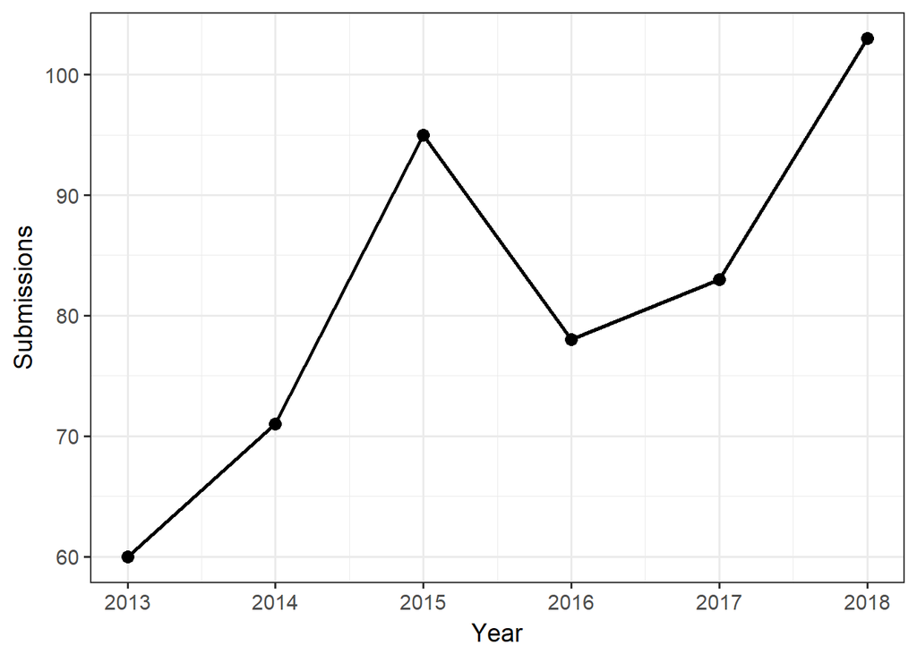

#### 6.7.3.2 Average attendance

Mean number of attendees per course tends to be highest for full day short courses and lowest for tutorials. Attendance is variable but it doesn’t seem to be trending over time.

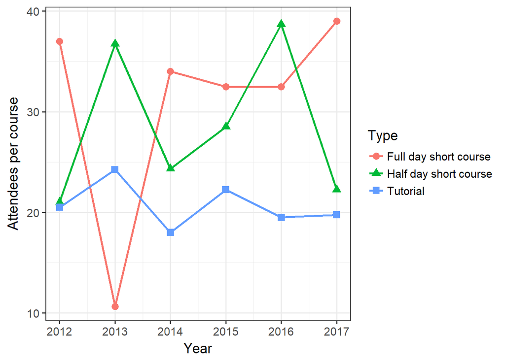

#### 6.7.3.3 Total Attendance

Total short course attendance is strongly related to total registration at CSP. This is based on a history of offering 5 rooms full of short courses on 1 day. We don’t know what the effect would of changing the number of short courses until we do it. Our hope is that we would see an increase in total course attendance (for the given number of registrations) after increasing the number of short courses.

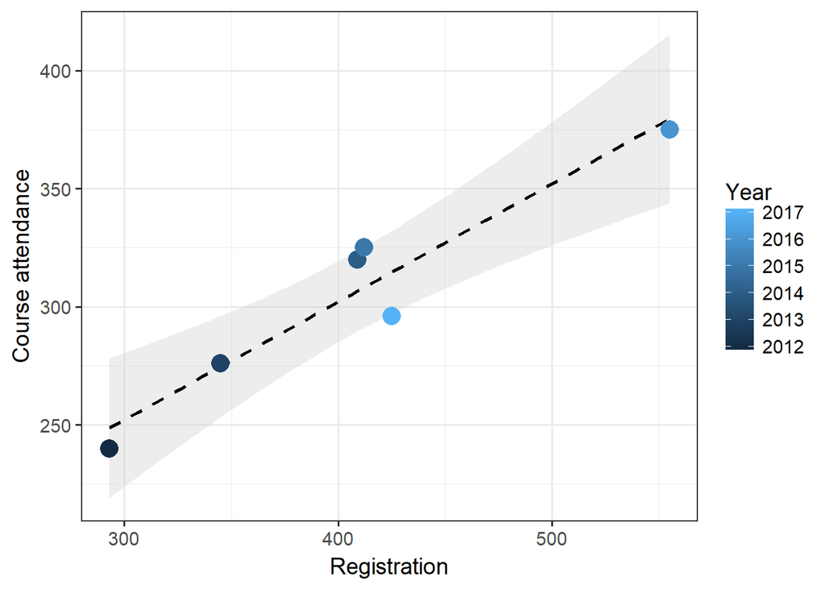

#### 6.7.3.4 CSP2019

- Feb 2019, east coast
- Bids for Hotels are out now
- Location should be known around October 2017
- Budget prepared in April 2018
- Could possibly add more rooms before this time, if hotel has space

#### 6.7.3.5 Group feedback

We went around the room and shared our thoughts on the short course proposal

- Donna: Not convinced that an increase in short courses is needed. Too many submissions is a good problem to have.
- Wendy: No increase in short courses unless a compelling reason to do so.
- Eric V.: If registration increases, then increase short courses. Perhaps add just 1 additional room (rather than 3).
- Mary: Don’t see need to increase short courses.
- Mac: Would like to see short courses offered over two days (rather than 1) so he could attend more. Perhaps add 2 rooms.
- Kathy: CSP has room to grow. Could increase short courses.
- Amanda: Any proposal to increase short courses should come with a justification for ASA budget approval. Also, keep in mind that when hotel bids go out, a target number of attendees is included (500), which translates to a cap of about 550. If we want more than this at CSP, we need to increase the numbers included in the bid.
- Jinguo: Doesn’t expect number of attendees to increase with increased short course offerings.

## 6.8 Nov 1, 2017

*[Minutes by Jean]*

- Present: Amanda Conageski (ASA), Colleen Mangeot, David Corliss, Donna LaLonde (ASA), Eric Vance (vice chair), Grace Kim, Isabella Ghement, Jean Adams (chair), Jinguo Gao, Kim Love, Laura Schweitzer, Mac Turner, Mary Kwasny, Sylvia Dohrmann, and Wendy Martinez.
- Absent: Ed Jones and Eric Stephens.

### 6.8.1 Review accomplishments since last meeting (Aug 1)

- Oral abstracts placed into schedule - Eric V., Vice Chair
- *Greatest Hits of CSP* submitted as an invited session for JSM2018 - Kim. We have not heard back. **Kim** will check. If it was not accepted, she will resubmit as a topic contributed session.
  - Jennifer Van Mullekom, Virginia Tech - Statistical Presentation Power: How to Reveal Your ‘X Factor’!!!
  - Ed Jones, Texas A&M University - Integrating Text Analytics with Traditional Structured Analytics
  - Mark Ward, Purdue University - Data Scraping, Parsing, Wrangling, and Cleaning
  - Naomi Robbins, NBR Independent Consultant - How to Avoid Some Common Graphical Mistakes
  - Eric Vance, University of Colorado at Boulder - Chair
- 60 Posters were selected - Grace, chair of Poster subcommittee
- [Practical Computing Demos](https://ww2.amstat.org/meetings/csp/2018/onlineprogram/index.cfm?SessionTypeID=148) accepted - Jean, Chair
- [Keynote](https://ww2.amstat.org/meetings/csp/2018/onlineprogram/index.cfm?SessionID=201845) title and abstract submitted - Lisa LaVange, US FDA Center for Drug Evaluation and Research, ASA president elect
- Website updated
- Housing open (Jan 22)
- Early registration open (Jan 10)
- Abstract editing open (Nov 17)
- Bids are out now for CSP2019. Should know the city and date soon (either Feb 7-9 or Feb 14-16)

### 6.8.2 Face-to-Face initiatives

- Mentoring program - **Wendy** will lead
- Last AM and PM announcements for lunch and dinner - **David** will draft a slide with the announcements/reminders for each time slot (Fri AM, Fri PM, and Sat AM) and share with F2F group.
- Plenary session icebreaker/greet your neighbor - **Jean**
- Thanking speakers after CSP - Chairs thank instructors and presenters at time of conference. Ambassadors thank presenters after conference via email. Need to make sure that instructors are also thanked afterwards via email. **Eric V.** will add this to Chair checklist.
- Affiliation color sticker - **Kim** will hand these out at a table next to the registration desk.
- 1st-time attendee ribbon - ditto.
- Face-to-face email sent to attendees before CSP - Discussed several print versions (paper in registration packet, papers next to stickers table, verbage in printed program). Printed program was most appealing. **F2F** will take the lead. Any items to be included must be sent to Amanda by **Jan 2**.
- Evening outing to include more options for Friday night. - **Jinguo**, **David** (microbrew tour), and **Wendy** (food truck tour) all had ideas. **All** of us will investigate other ideas for Portland and report back to Eric V. by **Nov. 15**.
- Speed networking organized and advertised more effectively. - We wondered if this was simply too extraverted an exercise for most of our attendees. Decided to drop it from CSP2018.
- Theme based group dinners - Ideas for dinners were suggested by **Eric V.** (academic stat. labs), **Jinguo** (consultants), **David** (data for good). General approach will be to make a restaurant reservation and cap attendance at 8 people. David suggested that we open it up to all registrants to see if any of them want to host a theme dinner. Amanda suggested that we use the online CSP2018 Community Forum to reach out.
- Other ideas - Isabella suggested an alternative idea, a quiet space or a meditation. Colleen volunteered to lead. Jean encouraged Isabella and/or Colleen to flesh this out and pitch it to the F2F group. **All** of us can bring other ideas to the F2F group.

### 6.8.3 Next (not covered in meeting)

- Who plans to attend CSP in Portland? - **All** please respond to Jean with a Yes/No.
- Oral session Ambassadors - **Jean** will make assignments from committee members (need not be going to Portland).
- Course Chairs - **Eric V.** will recruit from committee members going to Portland.
- Oral and Poster session Chairs - **Amanda** will forward list of volunteers to **Eric V.** Note, Eric, that there will be far more volunteers than slots, but keep them all in the spreadsheet because your original selections (based on first come, first served, and theme) will be modified iteratively as volunteers drop out.
- Review of on-line program - **All** will visit the on-line program and let Jean know of any suggested changes by **Dec 15**.
- Next meeting Jan 16-19.

## 6.9 Jan 16, 2018

*[Minutes by Jean]*

- Present: Amanda Conageski (ASA), Colleen Mangeot, David Corliss, Donna LaLonde (ASA), Eric Stephens, Eric Vance (vice chair), Grace Kim, Jean Adams (chair), Kim Love, Laura Schweitzer, Mac Turner, Mary Kwasny, Sylvia Dohrmann, and Wendy Martinez.
- Absent: Ed Jones, Isabella Ghement, and Jinguo Gao.

### 6.9.1 Face-to-Face ideas - Eric V.

- **Kim** - Introduction to keynote speaker, including ice breaker (Kim and Jean will talk on the side)
- Friday dinners - **Eric V.** will post on the CSP community and then follow up with paper sign ups at the conference
- Meditation room - **Colleen** will host some 15-minute guided meditations, perhaps one in the morning and one in the evening, with 15 minutes of quiet time afterwards, this will happen in an available room on a different floor, available for other use at other times (one sponsor wants to use it for Friday lunch, 12:30-1:50)
- Mentor program - **Donna** & **Wendy** will organize, **Mary** offered to help as well.

### 6.9.2 Poster judging

Grace is the chair, but will not be attending CSP. **Sylvia** agreed to chair. She will serve as a judge along with **David**, **Mac**, and **Laura**. See guidelines above.

### 6.9.3 Closing session

**Eric V.** will chair, asked for volunteer panelists: **Mary**, **Sylvia**, **Laura**, **Kim** all offered to help

### 6.9.4 Group messaging at CSP

**Sylvia** offered to reprise her organization of a **Group Me** group messaging app, one for all steering committee members at CSP (as far as I know: Colleen, David, Ed, Eric V., Kim , Laura, Mac, Mary, Sylvia, and Wendy) and one for all poster judges (see above).

### 6.9.5 Post-conference survey - Jean

Updated for CSP2018 here

### 6.9.6 Short course chairs - Eric V.

**Amanda** will share email addresses, **David** will share an example email, Sylvia suggests that we remind them that the internet connection may be intermittent, **David** will be available during the short courses to ensure things run smoothly.

- SC1 **Colleen**
- SC2 **Wendy**
- SC3 **Mac**
- SC4 **David**
- SC5 **Mary**
- SC6 **Eric V.**
- SC7 **Mac**
- SC8 **Laura**
- T1 **Eric V.**
- T2 **Kim**
- T3 **Mac**
- T4 **Sylvia**

### 6.9.7 Government shutdown

If the US government shuts down between now and the conference, we may suddenly lose some speakers, and we will lose our chair (Jean will not be allowed to even access her email, Eric V. will be acting chair). If a budget is signed, we may have a sudden surge of government attendees registering. Amanda says that 17 registrants marked that they worked for a national government. After our call, Jean looked at the on-line program for potentially affected courses or oral sessions. There were 6: Keynote (FDA), CS04 (CDC), CS07 (BLS), CS08 (FDA), CS16 (USDA), and CS18 (DOE).